# Exam 1 Review Problems — Solutions

STAT 251 Section 01

2026-09-16

Worked solutions. Answers are shown in red.

These problems cover everything on Exam 1: Weeks 1 through 3, up to and including cumulative distributions. They are **more computational than the exam** by design. The exam asks you to interpret values, identify equations and read plots; these ask you to work the arithmetic behind them.

Work them by hand. Every dataset is small enough to do on paper, and a calculator is fine.

## Problem 1 — The anatomy of data

A researcher recorded the following information for each of six trees in a city park.

| Tree ID | Species | Health rating | Branches removed | Trunk width (cm) |
| --- | --- | --- | --- | --- |
| T-01 | Maple | Good | 3 | 31.4 |
| T-02 | Oak | Fair | 0 | 58.2 |
| T-03 | Maple | Excellent | 5 | 22.7 |
| T-04 | Pine | Good | 1 | 44.0 |
| T-05 | Oak | Poor | 8 | 61.9 |
| T-06 | Maple | Good | 2 | 27.5 |

**(a)** How many observations are in this data table, and how many variables? Which way round does a data table store them — one observation per row or one variable per row?

6 observations and 5 variables; one observation per row

A data table stores **one observation per row and one variable per column**. Each row here is a single tree – everything recorded about that one tree – and each column is one characteristic recorded for every tree. So counting rows counts observations and counting columns counts variables: 6 rows and 5 columns.  
Say it to yourself the right way round before you count. A table with 200 rows and 6 columns holds 6 variables measured on 200 observations, not the other way about.

**(b)** What is the value of $n$ for this sample?

$n = 6$

**(c)** Classify each of the four measured variables as nominal, ordinal, discrete or continuous.

| Variable | Your answer |
| --- | --- |
| Species | nominal |
| Health rating | ordinal |
| Branches removed | discrete |
| Trunk width (cm) | continuous |

**Species** is a category with no natural ordering, so nominal. **Health rating** is a category *with* an ordering – poor, fair, good, excellent – so ordinal. **Branches removed** counts things, so it takes whole-number values only: discrete. **Trunk width** is a measurement on a scale, recorded to a tenth of a centimetre, so continuous.  
Note that *Tree ID* is a label, not a measured variable – it identifies the observation rather than describing it.

**(d)** These six trees are a sample. Describe the population the researcher is presumably interested in, and say whether $N$ is known.

The population is all of the trees in the city park (or, more broadly, all trees the park service manages). $N$ is the number of trees in that population. Here it is not given – and unlike most populations we will meet, this one is finite and could actually be counted.

## Problem 2 — Statistics, parameters, and inference

A city has 8,500 registered bicycles. A researcher takes a random sample of 200 of them and finds that 46 have no working lights. She also measures the age of each sampled bicycle and finds a mean age of 6.2 years.

**(a)** Give the values of $N$ and $n$.

$N = 8{,}500$ and $n = 200$

**(b)** Show how to compute the sample proportion of bicycles with no working lights. Which symbol denotes it?

$\hat{p} = \frac{\text{number with no working lights}}{n} = \frac{46}{200} = 0.23$

The **sample** proportion is written $\hat{p}$. The hat marks it as a quantity computed from a sample. The corresponding population proportion – the fraction of all 8,500 bicycles with no working lights – is written $p$ and is unknown.

**(c)** For each quantity, say whether it is a **statistic** or a **parameter**, and give the symbol that denotes it.

| Quantity | Statistic or parameter | Symbol |
| --- | --- | --- |
| The mean age of the 200 sampled bicycles | statistic | $\bar{x}$ |
| The mean age of all 8,500 registered bicycles | parameter | $\mu$ |
| The proportion of the 200 sampled with no lights | statistic | $\hat{p}$ |
| The proportion of all 8,500 with no lights | parameter | $p$ |
| The standard deviation of the ages of the 200 sampled | statistic | $s$ |
| The standard deviation of the ages of all 8,500 | parameter | $\sigma$ |

Every row comes down to the same question: does the number describe the **200 bicycles measured** (a statistic) or **all 8,500** (a parameter)?  
The symbols come in pairs, one for each. Roman letters are the statistics and Greek letters the parameters – $\bar{x}$ against $\mu$, $s$ against $\sigma$, and $s^{2}$ against $\sigma^{2}$ for the variances. The proportions are the exception to the Roman-and-Greek pattern: the sample proportion wears a *hat*, $\hat{p}$, and the population proportion is the bare $p$.  
Note also that whether a number was measured directly has nothing to do with it. All 8,500 bicycles are registered, so $\mu$ and $p$ *could* be measured – they are still parameters, because they describe the population.

**(d)** The researcher reports the mean age of the 200 bicycles she measured, then uses it to estimate the mean age of all 8,500. Which of those two acts is descriptive statistics and which is inferential? Explain what makes the difference.

Reporting the mean of the 200 measured bicycles is **descriptive**: it summarizes the data in hand and claims nothing beyond it. Using that mean to estimate the mean age of all 8,500 is **inferential**: it reaches past the sample to a population that was never fully observed.  
The difference is not which data you have – both acts use the same 200 bicycles. It is *what you are claiming*: whether the conclusion stops at the sample or extends beyond it.

## Problem 3 — Reading the formulas

On the exam the formulas are provided **unlabeled** — the equations only, with no names. This problem is practice at telling them apart.

**(a)** Each equation below computes one of the quantities in the list. Write the name of the quantity next to its equation, and give the symbol it is denoted by.

> sample mean, from raw observations · sample mean, from a frequency table · sample mean, from a relative frequency table · population mean · sample proportion · population proportion · sample variance · sample standard deviation · range · interquartile range

| Equation | What it computes | Symbol |
| --- | --- | --- |
| $\dfrac{1}{n}\sum_{i=1}^{n} x_i$ | sample mean, from raw observations | $\bar{x}$ |
| $\sqrt{\dfrac{1}{n-1}\sum_{i=1}^{n}(x_i - \bar{x})^{2}}$ | sample standard deviation | $s$ |
| $Q3 - Q1$ | interquartile range | $IQR$ |
| $\sum_{x} x\,RF(x)$ | sample mean, from a relative frequency table | $\bar{x}$ |
| $\dfrac{1}{N}\sum_{i=1}^{N} x_i$ | population mean | $\mu$ |
| $\dfrac{\text{number of observations in the category}}{n}$ | sample proportion | $\hat{p}$ |
| $\max x - \min x$ | range | $\text{range}$ |
| $\dfrac{\text{number of observations in the category}}{N}$ | population proportion | $p$ |
| $\dfrac{1}{n}\sum_{x} x\,F(x)$ | sample mean, from a frequency table | $\bar{x}$ |
| $\dfrac{1}{n-1}\sum_{i=1}^{n}(x_i - \bar{x})^{2}$ | sample variance | $s^2$ |

Three things give each one away. The **divisor**: $n$ for a sample mean, $N$ for a population mean, $n-1$ for a variance. The **square root**, which is the only difference between $s^2$ and $s$. And whether the deviations are **squared** at all.  
The two that get confused most often are the middle pair: $s^2$ and $s$ are the same expression apart from the root, so check for it every time.  
Notice that the two *pairs* work the same way. A sample mean and a population mean are the same sum, divided by $n$ or by $N$; a sample proportion and a population proportion are the same count, divided by $n$ or by $N$. When the equation is handed to you without a label, the bottom of the fraction is what tells you whether you are looking at a statistic or a parameter.  
**The three means.** All three are $\bar{x}$ – the same number, computed from whatever you happen to have been given. Tell them apart by what goes into the sum: raw observations $x_i$, or a value times its frequency $x\,F(x)$, or a value times its *relative* frequency $x\,RF(x)$. The frequency version still has to be divided by $n$ at the end; the relative frequency version **must not be**, because $RF(x) = F(x)/n$ has already done that division. Dividing by $n$ twice is the single most common error here.

**(b)** *(notation)* Answer each in a few words.

| Question | Your answer |
| --- | --- |
| What does $n$ stand for? | the number of observations in the **sample** |
| What does $N$ stand for? | the number of observations in the **population** |
| What does the *hat* on $\hat{p}$ tell you? | that it is computed from a sample, and estimates the parameter $p$ |
| What does $\sum_{i=1}^{n} x_i$ mean? | add up the observations, starting at the first and running through the $n^{th}$: $x_1 + x_2 + \cdots + x_n$ |

**(c)** Consider the following sample of five observations of a quantitative variable $X$:

$$X = \{ 2, \ 5, \ 6, \ 9, \ 13
\}$$

**Show how to compute** the mean $\bar{x}$ and the standard deviation $s$.

$\bar{x} = \dfrac{1}{n}\sum_{i=1}^{n} x_i = \dfrac{2 + 5 + 6 + 9 + 13}{5} = \dfrac{35}{5} = 7$  
$s = \sqrt{\dfrac{1}{n-1}\sum_{i=1}^{n}(x_i - \bar{x})^{2}} = \sqrt{\dfrac{(2-7)^2 + (5-7)^2 + \cdots + (13-7)^2}{5-1}} = \sqrt{\dfrac{70}{4}} = \sqrt{17.5} \approx 4.18$

**(d)** Now consider the following sample of ten observations of a qualitative variable $Y$, the way each of ten students travelled to campus:

$$\begin{gathered}
Y = \{ \text{Bus}, \ \text{Walk}, \ \text{Bike}, \ \text{Bus}, \
\text{Walk}, \ \text{Bus}, \\
\text{Car}, \ \text{Bus}, \ \text{Walk}, \ \text{Bike} \}
\end{gathered}$$

**Show how to compute** the proportion of observations in the category **Bus**.

$\hat{p} = \dfrac{\text{number of observations in the category}}{n} = \dfrac{4}{10} = 0.4$  
So 40% of the sample travelled by bus.

## Problem 4 — The distribution of a qualitative variable

A campus coffee stand recorded the drink ordered by each of 20 customers one morning:

$$\begin{gathered}
X = \{ \text{Latte}, \ \text{Drip}, \ \text{Mocha}, \ \text{Latte}, \
\text{Drip}, \ \text{Espresso}, \\
\text{Latte}, \ \text{Drip}, \ \text{Latte}, \ \text{Mocha}, \
\text{Drip}, \ \text{Latte}, \\
\text{Espresso}, \ \text{Drip}, \ \text{Mocha}, \ \text{Latte}, \
\text{Drip}, \ \text{Latte}, \\
\text{Mocha}, \ \text{Latte} \}
\end{gathered}$$

**(a)** Complete the frequency and relative frequency table.

| Drink | Frequency $F(x)$ | Relative frequency $RF(x)$ |
| --- | --- | --- |
| Drip | 6 | 0.30 |
| Espresso | 2 | 0.10 |
| Latte | 8 | 0.40 |
| Mocha | 4 | 0.20 |

**(b)** What is the modal category?

Latte, with a frequency of 8

**(c)** Draw a bar graph of the distribution on the axes below.

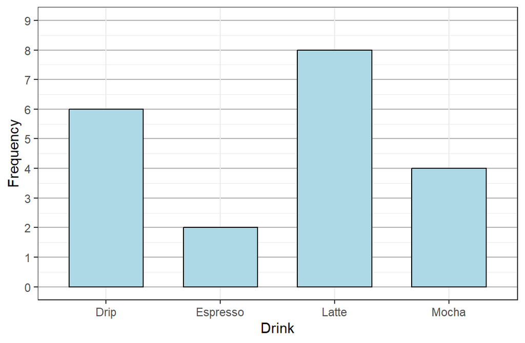

**(d)** A classmate suggests drawing a **histogram** of the drinks instead. Why will that not work? Of the displays we have met — bar graph, pie chart, Pareto chart, histogram, stem-and-leaf plot, dot plot, boxplot — say which are for qualitative data and which require a quantitative variable.

| Display | Qualitative or quantitative? |
| --- | --- |
| Bar graph | qualitative |
| Pie chart | qualitative |
| Pareto chart | qualitative |
| Histogram | quantitative |
| Stem-and-leaf plot | quantitative |
| Dot plot | quantitative |
| Boxplot | quantitative |

A histogram needs a **number line** to bin values along, and drink type has no numeric axis to put one on – there is no distance between a latte and a mocha to divide into intervals. The right display for a qualitative variable is a **bar graph**: one separated bar per category, in no meaningful order.  
The separation matters. A histogram’s bars touch, because the bins are adjacent pieces of a continuous scale; a bar graph’s bars are drawn apart, because the categories are not next to each other in any sense at all.  
The other two qualitative displays are variations on the bar graph: a **pie chart** shows each category’s share of the whole, and a **Pareto chart** is a bar graph with the categories sorted by decreasing frequency. The four quantitative displays all need numeric values – a stem-and-leaf plot splits digits into stems and leaves, a dot plot stacks points on a number line, and a boxplot is built from quartiles, which cannot be computed for categories that cannot be put in order.

**(e)** Would it make sense to add a *cumulative relative frequency* column to the table in part (a)? Explain.

No. Cumulative relative frequency is the proportion of observations *less than or equal to* a given value, and that phrase only means something if the values can be put in order. Drink type is a **nominal** variable – there is no sense in which a mocha is ‘less than’ a latte – so there is no meaningful order to accumulate along.  
Had the variable been ordinal, say drink size (small, medium, large), a cumulative relative frequency column would be perfectly sensible.

## Problem 5 — Frequency tables and the mean from a table

Twenty-five households were asked how many vehicles they own. The responses are summarized below.

| Vehicles $x$ | Frequency $F(x)$ | Relative frequency $RF(x)$ | Cumulative relative frequency $CRF(x)$ |
| --- | --- | --- | --- |
| 0 | 3 | 0.12 | 0.12 |
| 1 | 9 | 0.36 | 0.48 |
| 2 | 8 | 0.32 | 0.80 |
| 3 | 4 | 0.16 | 0.96 |
| 4 | 1 | 0.04 | 1.00 |

**(a)** Fill in the blank entries in the table. Remember that the frequencies must add to $n$, the relative frequencies must add to $1$, and each cumulative relative frequency is the running total of the relative frequencies above it.

**The missing frequency.** The frequencies have to add to $n = 25$, and the four that are given add to $3 + 9 + 8 + 1 = 21$, so $F(3) = 25 - 21 = 4$.  
**The missing relative frequencies.** $RF(x) = F(x)/n$: $RF(1) = 9/25 = 0.36$, $RF(3) = 4/25 = 0.16$, $RF(4) = 1/25 = 0.04$. As a check, the column now adds to $0.12 + 0.36 + 0.32 + 0.16 + 0.04 = 1.00$.  
**The missing cumulative relative frequencies.** Each one is the previous $CRF$ plus the current $RF$: $CRF(2) = 0.48 + 0.32 = 0.80$ and $CRF(4) = 0.96 + 0.04 = 1.00$. The last $CRF$ is always $1.00$ – if yours is not, something above it is wrong.

**(b)** Show how to compute the mean number of vehicles using the **frequency** from the table above.

$\bar{x} = \dfrac{1}{n}\sum_{x} x\,F(x) = \dfrac{0(3) + 1(9) + 2(8) + 3(4) + 4(1)}{25} = \dfrac{0 + 9 + 16 + 12 + 4}{25} = \dfrac{41}{25} = 1.64$ vehicles.

**(c)** Now show how to compute the mean again using the **relative frequency** from the table above, and confirm you get the same answer.

$\bar{x} = \sum_{x} x\,RF(x) = 0(0.12) + 1(0.36) + 2(0.32) + 3(0.16) + 4(0.04) = 0 + 0.36 + 0.64 + 0.48 + 0.16 = 1.64$ vehicles.  
The two formulas are the same calculation. Dividing by $n$ at the end (the frequency version) and dividing by $n$ at the start to build the relative frequencies (this version) get you to the same place. This is also why you must not divide by $n$ *again* in the relative frequency version.

**(d)** What proportion of these households own 2 or fewer vehicles?

$0.80$

**(e)** Use the table to find the median number of vehicles owned.

**Median is 2 vehicles.** There are two ways to get there.  
**From the frequencies.** With $n = 25$ the median is the $13^{th}$ value once the data is put in order. The first $3$ values are $0$s and the next $9$ are $1$s, which takes you through the $12^{th}$ value, so the $13^{th}$ value is a $2$.  
**From the $CRF$ column.** The median is the $50^{th}$ percentile, so read down the $CRF$ column for where it first reaches $0.50$: it is $0.48$ at $x = 1$ and $0.80$ at $x = 2$, so the median is $2$.

## Problem 6 — Binned frequency tables and histograms

The following are the times, in seconds, that 16 users took to complete a task on a website.

$$\begin{gathered}
X = \{ 12.4, \ 14.1, \ 15.8, \ 16.2, \ 17.5, \ 18.0, \ 18.3, \ 19.1, \
20.2, \ 20.6, \\
21.7, \ 22.4, \ 23.9, \ 25.1, \ 26.8, \ 28.4 \}
\end{gathered}$$

**(a)** Complete the frequency table using the intervals given. (The bins are always handed to you — here, on the exam, and in the homework. Choosing the number of bins or the bin width yourself is never asked for.)

| Time (seconds) | Frequency $F(x)$ | Relative frequency $RF(x)$ |
| --- | --- | --- |
| $12 < x \leq 16$ | 3 | 0.1875 |
| $16 < x \leq 20$ | 5 | 0.3125 |
| $20 < x \leq 24$ | 5 | 0.3125 |
| $24 < x \leq 28.5$ | 3 | 0.1875 |

**(b)** Draw the histogram on the axes below.

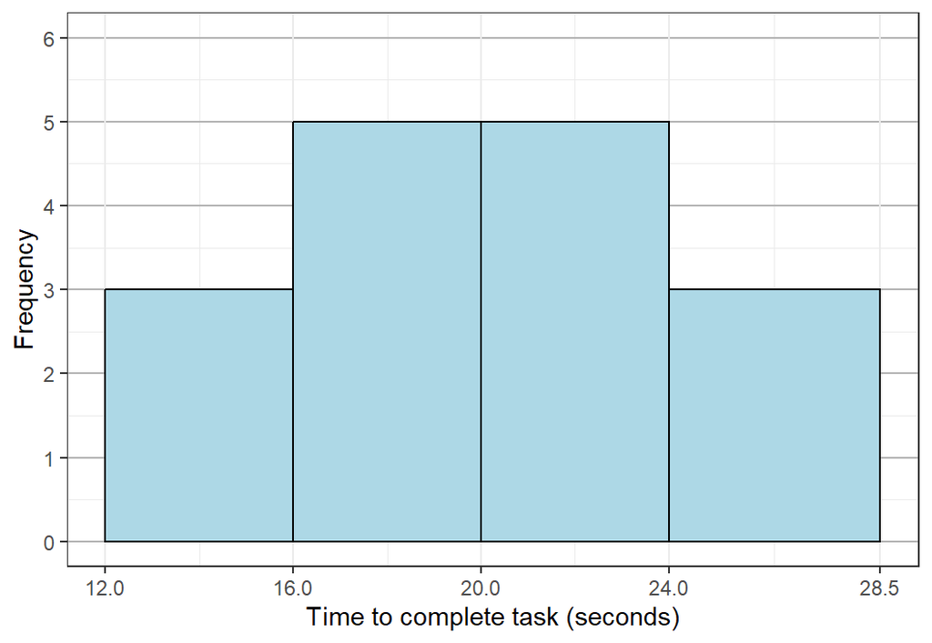

**(c)** Describe the shape of this distribution.

Roughly **symmetric and unimodal**, with the bulk of the observations in the two middle bins and the counts tapering off evenly at both ends. There is no long tail in either direction and no obvious gap, so nothing here looks like an outlier.

**(d)** A frequency table reports only how many observations fall in each interval.

1. Using **only** the table from part (a), what proportion of users finished the task in 20 seconds or less?
2. Name one quantity you could compute from the raw times listed above but **not** from the table alone, and say why the table cannot give it to you.

**(i)** The first two intervals cover everything up to 20 seconds, and they hold $3 + 5 = 8$ of the 16 users, so the proportion is $8/16 = 0.5$.  
**(ii)** The fastest or slowest individual time, or the exact mean or median. The table keeps only the *counts* per interval – it says five users finished between 16 and 20 seconds, but not what any one of those five times was, so there is nothing left to take a maximum or an average of.  
That loss of precision is the cost of binning. It buys a readable summary of the shape, which the raw list of 16 numbers does not give you.

## Problem 7 — Dot plots and stem-and-leaf plots

A biologist recorded the number of eggs in each of 15 birds’ nests:

$$\begin{gathered}
X = \{ 21, \ 24, \ 24, \ 27, \ 28, \ 31, \ 33, \ 33, \ 33, \ 35, \\
38, \ 41, \ 42, \ 44, \ 47 \}
\end{gathered}$$

**(a)** Construct a **stem-and-leaf plot**, using the tens digit as the stem.

```
  2 | 1 4 4 7 8
  3 | 1 3 3 3 5 8
  4 | 1 2 4 7
```

**(b)** Construct a **dot plot** on the number line below.

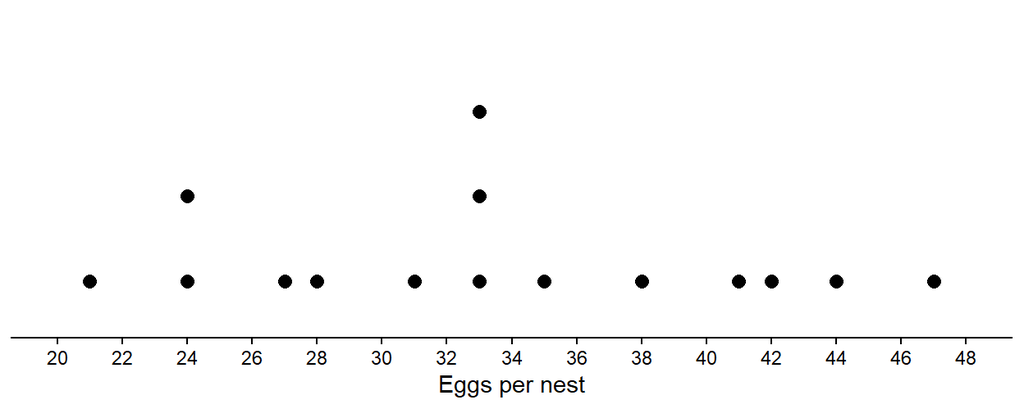

**(c)** What is the mode of this variable?

33 eggs, which occurs three times

**(d)** Is the mode a measure of the center of this distribution? Explain.

No – the mode is a measure of **location**. It tells you where the peak is, i.e. the most frequent value, not where the center is. Here the distribution happens to be roughly symmetric so the mode of 33 does land near the middle, but that is a coincidence of this data rather than a property of the mode.  
For a skewed distribution the mode can sit well away from the center, and a bimodal distribution has two modes with the center usually falling in the gap between them, where the data are sparsest.

## Problem 8 — Center, and what an outlier does to it

Consider the following five observations of a variable $X$, the number of minutes five customers spent in a shop:

$$X = \{ 6, \ 6, \ 9, \ 12, \ 17
\}$$

**(a)** Show how to compute the mean, the median and the mode.

| Statistic | Your answer |
| --- | --- |
| Mean $\bar{x}$ | $\bar{x} = \frac{1}{n}\sum_{i=1}^{n} x_i = \frac{6 + 6 + 9 + 12 + 17}{5} = \frac{50}{5} = 10$ minutes |
| Median | the $3^{rd}$ of 5 ordered values: 9 minutes |
| Mode | the most frequent value: 6 minutes |

**(b)** A sixth customer stays for **70 minutes**. Recompute the mean and the median with that observation included. Which of the two moved more, and why?

$\bar{x} = \frac{1}{n}\sum_{i=1}^{n} x_i = \frac{6 + 6 + 9 + 12 + 17 + 70}{6} = \frac{120}{6} = 20$ minutes.  
With $n = 6$ there is no single middle value, so the median is the average of the $3^{rd}$ and $4^{th}$ ordered values: $\frac{9 + 12}{2} = 10.5$ minutes.  
The **mean** moved far more – it doubled, from 10 up to 20 minutes – while the median moved from 9 to 10.5, a shift of a minute and a half.  
The mean uses the *value* of every observation, so a single very large value pulls it upward in proportion to how extreme it is. The median depends only on *position* in the ordered data; adding one more value at the top shifts the middle position over by half a place and nothing more.  
Notice too that after the outlier the mean of 20 minutes is larger than *every observation except the outlier itself*. It is no longer describing a typical customer at all.

**(c)** Which of the two is **resistant**? Give a one-sentence definition of that word.

The median is resistant.

A summary measure is **resistant** when a single extreme observation barely moves it. Whether a measure is resistant comes down to one thing: whether it uses the values of every observation, or only positions in the ordered data.

## Problem 9 — Percentiles and quartiles

The following are the ages of the 10 members of a community board, sorted:

$$X = \{ 29, \ 34, \ 38, \ 41, \ 45, \ 49,
\ 52, \ 56, \ 61, \ 67 \}$$

**(a)** Find the median, $Q2$.

$Q2 = (45 + 49)/2 = 47$, the average of the $5^{th}$ and $6^{th}$ of 10 ordered values

**(b)** Find $Q1$ and $Q3$ using the **method of halves** we use in this class.

Because $n = 10$ is even there is no middle value to set aside – the data splits cleanly into two halves of five. The lower half is $\{29, 34, 38, 41, 45\}$ and the upper half is $\{49, 52, 56, 61, 67\}$, so each quartile is just the middle value of its half:  
$Q1 = 38$ years and $Q3 = 56$ years.

**(c)** An eleventh member, aged $58$, joins the board. Find $Q1$, $Q2$ and $Q3$ for the new set of 11 ages. Remember that when $n$ is odd the median is **left out** of both halves.

The ordered ages are now $\{29, 34, 38, 41, 45, 49, 52, 56, 58, 61, 67\}$.  
With $n = 11$ the median is the single middle value, the $6^{th}$ age: $Q2 = 49$ years. Because $n$ is odd, that value is now dropped from both halves.  
The lower half is $\{29, 34, 38, 41, 45\}$, so $Q1 = 38$ years.  
The upper half is $\{52, 56, 58, 61, 67\}$, so $Q3 = 58$ years.  
Compare this with part (b): the method is the same both times. The only thing that changes is that an odd $n$ leaves you a middle value to drop, and an even $n$ does not.  
**If your calculator disagrees, read this.** Put these 11 ages into a calculator, a spreadsheet or R and you will very likely get $Q1 = 39.5$ and $Q3 = 57$ instead of the $38$ and $58$ above. Those answers are *not wrong* – they are a **different definition**, and there are several in circulation.  
**Tukey’s hinges**, which most boxplot routines draw, *keep* the median in both halves instead of dropping it. That is the one difference, and it is why the hinges here are $\text{median}(29,34,38,41,45,49) = 39.5$ and $\text{median}(49,52,56,58,61,67) = 57$. **Interpolating** methods, the default in most software, do something different again: they slide between the two neighbouring observations rather than landing on a data value at all.  
So: the hinges agree with this class whenever $n$ is **even** – check part (b), where both give $Q1 = 38$ and $Q3 = 56$ – and part ways only when $n$ is odd, because only then is there a median to drop. Interpolating methods can disagree either way. This class uses the **method of halves with the median excluded**, and that is the answer the exam wants whenever it says so.

**(d)** Using the original 10 ages, what is the $IQR$, and what does it measure?

$IQR = Q3 - Q1 = 56 - 38 = 18$ years

The IQR is the distance between $Q1$ and $Q3$, so it describes how spread out the **middle 50%** of the data are. Because it ignores the extreme ends of the distribution entirely, it is highly resistant to outliers.

**(e)** In the original 10 ages, the board member aged 61 is at roughly what percentile? Answer in a sentence that says what that means.

Nine of the 10 members are aged 61 or younger, so 61 sits at about the $9/10 = 90^{th}$ percentile: roughly 90% of the board is at or below that age, and only one member is older.

## Problem 10 — Deviations, variance and standard deviation

A quality inspector took three packets of ground coffee off a filling machine and weighed each one, in grams:

$$X = \{ 48, \ 54, \ 57 \}$$

The sample mean of these three packets is $\bar{x} = \dfrac{159}{3} = 53$ grams.

**(a)** Complete the deviation table below, then add up **each** of the two columns you filled in. You will need the second of those totals again in part (c).

| $x_i$ | $x_i - \bar{x}$ | $(x_i - \bar{x})^2$ |
| --- | --- | --- |
| 48 | -5 | 25 |
| 54 | 1 | 1 |
| 57 | 4 | 16 |

The deviations are $48 - 53 = -5$, $54 - 53 = 1$ and $57 - 53 = 4$ grams, and their squares are $25$, $1$ and $16$.  
The deviation column sums to **0**, and the squared deviation column sums to $25 + 1 + 16 = 42$.  
The deviations summing to zero is not a property of these three numbers – it happens for every dataset, because the mean is the balancing point. That is exactly why the variance squares the deviations before adding them: without squaring, the positives and negatives always cancel and you learn nothing.

**(b)** A fourth packet comes off the machine weighing **63 grams**. Using the sample mean $\bar{x} = 53$ grams from the three packets above, compute this packet’s deviation from the mean and interpret what that number tells you.

$x - \bar{x} = 63 - 53 = +10$ grams.  
This packet weighs 10 grams *more* than the average of the three packets already measured. A deviation carries both a size and a sign: the size is how far the observation sits from the mean in the units of the data (grams here), and the positive sign says it sits *above* the mean. A packet weighing 43 grams would have deviation $-10$ grams – the same distance from the mean, on the other side.

**(c)** Show or explain how to compute the sample variance $s^2$ from the table you filled in above, and then the sample standard deviation $s$.

The squared deviation column is the sum the variance formula needs. Add that column up and divide by $n - 1$:  
$s^{2} = \dfrac{1}{n-1}\sum_{i=1}^{n}(x_i - \bar{x})^{2} = \dfrac{25 + 1 + 16}{3 - 1} = \dfrac{42}{2} = 21$ grams squared  
$s = \sqrt{s^{2}} = \sqrt{21} \approx 4.58$ grams

**(d)** Two students propose simpler measures of spread. Explain what is wrong with each.

1. *“Just average the deviations:”* $\;\dfrac{1}{n}\sum_{i=1}^{n}(x_i - \bar{x})$
2. *“Fine — square them first, then just add them up:”* $\;\sum_{i=1}^{n}(x_i - \bar{x})^{2}$ Consider two samples that are equally spread out, one with $n = 3$ packets and one with $n = 300$.

**(i)** The deviations **always sum to zero**, for every dataset – that is what part (a) showed, and it is not a coincidence of these three packets. So this proposal returns $0/n = 0$ for tightly packed data and for wildly scattered data alike. It carries no information about spread at all. Squaring is what fixes it: it strips the signs, so nothing cancels and every observation contributes something positive.  
**(ii)** Squaring fixes the cancelling, but this proposal is a **total** rather than a typical amount, so it grows simply by adding more observations. Every packet contributes a positive squared deviation, so the sample of 300 would return a far larger value than the sample of 3 even though the two are equally spread out. A measure of spread has to be comparable across samples of different sizes, and a running total is not.  
Dividing by something that grows with the sample size is what turns the total into an *average* squared deviation. That is the whole job of the divisor – and the sample variance is exactly these two repairs applied at once: square the deviations, then divide.

**(e)** The sample variance divides by $n - 1$, but the sample mean divides by $n$. Why the difference?

The $n$ deviations are **not $n$ independent pieces of information**. They are measured from $\bar{x}$, which was itself computed from the very same data, and that forces them to sum to zero. So once you know any $n - 1$ of them the last one is determined – it has to be whatever value makes the total zero.  
Here that is easy to see. The three deviations are $-5$, $1$ and $4$. Tell me the first two and I can tell you the third without looking at the data: it must be $+4$, because nothing else sums to zero. Only **two** of the three were ever free to vary.  
That count – $n - 1$ – is the **degrees of freedom**, and it is what the variance divides by: the number of independent pieces of information the deviations actually carry, not how many numbers were written down. Dividing by $n$ instead would systematically *under*estimate the population variance $\sigma^{2}$; dividing by $n - 1$ is what makes $s^{2}$ unbiased.  
The sample mean has no such constraint – the $n$ observations are genuinely $n$ free values – so it divides by $n$.

**(f)** State the units of $\bar{x}$, of $s^2$ and of $s$.

| Quantity | Units |
| --- | --- |
| $\bar{x}$ | grams |
| $s^2$ | grams squared |
| $s$ | grams |

Squaring the deviations squares their units too, which is why the variance is in grams squared – a quantity nobody can picture. Taking the square root undoes it and puts $s$ back on the scale of the original data, where it reads as roughly the typical distance of a packet from the mean weight.

**(g)** Show how to compute the range. Which is the better description of the spread of this data, the range or the standard deviation, and why?

Range $= \max x - \min x = 57 - 48 = 9$ grams.  
The **standard deviation** is the better description here. The range is built from the two most extreme observations and *nothing else*: here it ignores the middle packet entirely, and in a larger sample it would ignore almost all of the data. It also moves by the full amount if either endpoint changes. The standard deviation uses every observation.  
The range is worth reporting as a quick descriptive fact, but it is almost never used as *the* measure of spread.

## Problem 11 — Five-number summary, boxplots and outliers

A clinic recorded the number of days between a referral and an appointment for 12 patients:

$$\begin{gathered}
X = \{ 3, \ 5, \ 6, \ 8, \ 9, \ 11, \ 12, \ 14, \ 15, \ 17, \\
19, \ 58 \}
\end{gathered}$$

**(a)** Give the five-number summary. Use the method of halves for the quartiles.

| Minimum | Q1 | Median | Q3 | Maximum |
| --- | --- | --- | --- | --- |
| 3 | 7 | 11.5 | 16 | 58 |

$n = 12$ is even, so there is no middle value to leave out: the median is the average of the $6^{th}$ and $7^{th}$ values, $Q2 = (11+12)/2 = 11.5$ days, and the data splits cleanly into two halves of six.  
The lower half is $\{3,5,6,8,9,11\}$ with median $Q1 = (6+8)/2 = 7$; the upper half is $\{12,14,15,17,19,58\}$ with median $Q3 = (15+17)/2 = 16$.

**(b)** Show how to compute the $IQR$ and both outlier boundaries.

$IQR = Q3 - Q1 = 16 - 7 = 9$ days, so $1.5 \times IQR = 13.5$.  
Lower boundary $= Q1 - 1.5 \times IQR = 7 - 13.5 = -6.5$ days.  
Upper boundary $= Q3 + 1.5 \times IQR = 16 + 13.5 = 29.5$ days.  
Nothing can fall below $-6.5$ days, so only the upper boundary can flag anything *in this particular dataset*. That is a fact about these 12 waits, not a rule – always work out both boundaries and check against both. Part (g) is a case where the flagged value is at the low end.  
**Two names, one thing.** These two positions are called the **lower boundary** and **upper boundary** here and on the exam. The Week 3 lecture notes call them the lower and upper **fences**. The words are interchangeable – same formula, same two numbers.

**(c)** Which observations, if any, does the $1.5 \times IQR$ rule flag as outliers?

Just one: the 58-day wait, which is above the upper boundary of 29.5

**(d)** Draw the boxplot on the axis below. Be careful about where the right whisker ends.

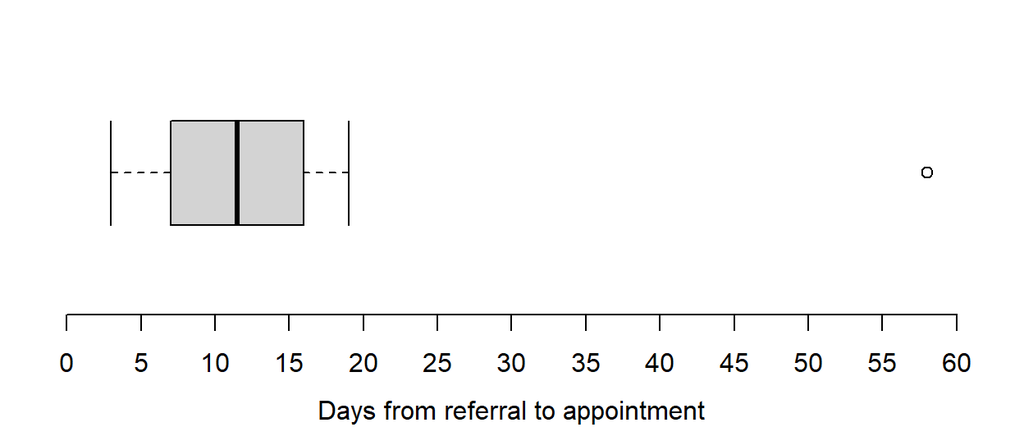

The right whisker stops at **19**, the largest observation that is still at or below the upper boundary of 29.5 – *not* at the maximum of 58, and not at the boundary itself. A whisker always ends on an actual data value. The 58 is drawn as its own point beyond the whisker.  
The left whisker runs all the way out to the minimum of 3, because nothing is flagged at the low end.

**(f)** The clinic manager wants to delete the 58-day wait because it is “clearly a mistake.” What would you tell her?

That being flagged by the $1.5 \times IQR$ rule is an **arithmetic result, not a verdict**. The rule reports only that a value sits unusually far from the middle half of the data; it cannot distinguish a recording error from a genuinely unusual case, and it marks the observation as worth a second look rather than as wrong.  
A 58-day wait is entirely plausible – it may be the single most important number in the dataset for a manager trying to improve scheduling. Deleting it because a rule flagged it would throw away real information.

**(g)** A second clinic reports its own referral waits, for 7 patients:

$$W = \{ 1, \ 14, \ 16, \ 18, \ 21, \ 22,
\ 33 \}$$

Find $Q1$, $Q3$ and both boundaries, and say which observations the $1.5 \times IQR$ rule flags. Check **both** boundaries before you answer.

$n = 7$ is odd, so the median – the $4^{th}$ value, $18$ days – is **dropped from both halves**. The lower half is $\{1, 14, 16\}$, so $Q1 = 14$; the upper half is $\{21, 22, 33\}$, so $Q3 = 22$.  
$IQR = 22 - 14 = 8$ days, so $1.5 \times IQR = 12$.  
Lower boundary $= 14 - 12 = 2$ days.  
Upper boundary $= 22 + 12 = 34$ days.  
**One outlier: the 1-day wait**, which falls below the lower boundary of 2.  
Two traps here, and the exam is fond of both. First, the flagged value is the *smallest* one – check the low boundary as well as the high one, every time, or you will report no outliers at all. Second, the 33-day wait **is not an outlier**: it is the largest value, and it looks extreme next to the rest, but $33 < 34$, so it sits inside the boundary. It is where the right whisker would stop.  
And as in part (f), a 1-day wait is not an error to be deleted. It is most likely an urgent case seen straight away.

**(h)** Why is it worth drawing a histogram or dot plot alongside a boxplot, rather than relying on the boxplot alone?

A boxplot is drawn from just **five numbers** plus whatever the outlier rule flags. That is enough to show center, spread, skew and outliers – but it says nothing at all about how the observations are arranged *between* those five positions. In particular a boxplot **cannot show multiple peaks or gaps**.  
So two variables with very different shapes can draw nearly the same box. A **bimodal** variable, piled into two separate clusters, and a roughly **uniform** one, spread evenly across the same range, can share all five numbers and therefore share a boxplot. The Old Faithful waiting times are the standing example: the boxplot gives no hint of the two clusters that the histogram makes obvious at a glance.  
A histogram or dot plot recovers exactly the information the five-number summary throws away – **modality and gaps**, where the data are dense and where they are sparse. Read the two together.

## Problem 12 — Cumulative distributions

A librarian recorded the number of books checked out by each of 20 patrons in one hour.

**(a)** Complete the table.

| Books $x$ | Frequency $F(x)$ | Relative frequency $RF(x)$ | Cumulative relative frequency $CRF(x)$ |
| --- | --- | --- | --- |
| 0 | 6 | 0.30 | 0.30 |
| 1 | 7 | 0.35 | 0.65 |
| 2 | 3 | 0.15 | 0.80 |
| 3 | 2 | 0.10 | 0.90 |
| 4 | 1 | 0.05 | 0.95 |
| 5 | 1 | 0.05 | 1.00 |

**(b)** Plot the cumulative distribution on the axes below. Remember it is a **step function**: flat between observed values, jumping at each one.

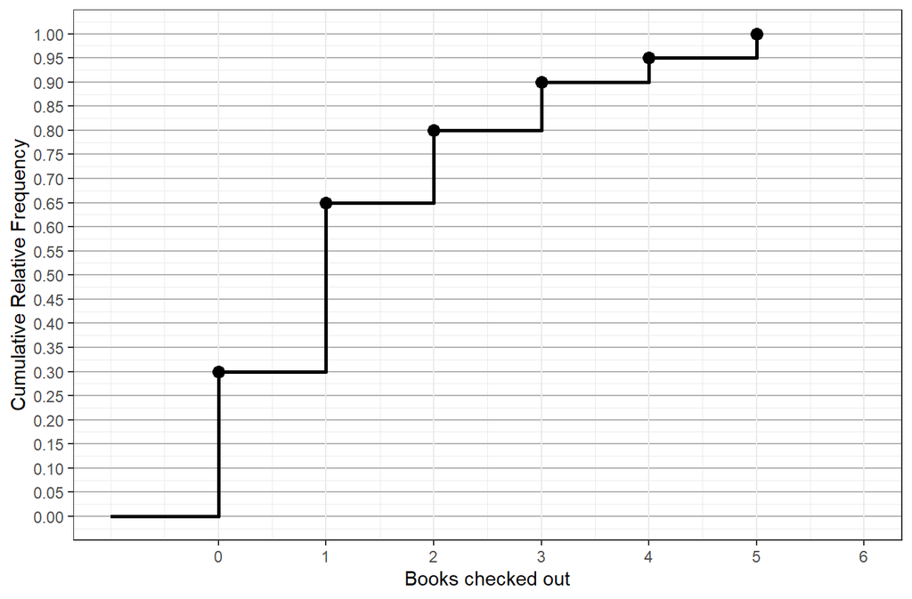

**(c)** Use the plot to find $Q1$, the median, and $Q3$.

Read across from $0.25$, $0.50$ and $0.75$ on the $y$-axis to the curve, then drop to the $x$-axis. Each of the three readings crosses a jump:  
$Q1 = 0$ books, $Q2 = 1$ book, $Q3 = 2$ books.  
Check them against halving the ordered data – they agree. The cumulative distribution is not a new definition of a quartile, just a faster way to read one off, and unlike halving it gives you *any* percentile.

**(d)** What proportion of patrons checked out 2 or fewer books?

$0.80$, read straight off the $CRF$ column at $x = 2$

**(e)** Describe the shape of this distribution, and say whether the mean will be greater than, less than, or equal to the median.

The distribution is **skewed right**: most of the patrons are piled up at 0 and 1 book – $13$ of the $20$, so nearly two thirds of them – and the frequencies then fall away to a thin tail of $3, 2, 1, 1$ stretching out to 5 books. On the cumulative plot the same thing shows up as a curve that climbs steeply over the first two jumps and is almost flat after that.  
A right skew pulls the mean toward the long tail while leaving the median where it is, so the **mean is greater than the median**. Here the mean is $28/20 = 1.4$ books against a median of 1 – the handful of patrons checking out 4 and 5 books drags the mean up, but they move the middle value not at all.

## A note on the exam

These solutions do more arithmetic than the exam requires. Exam 1 asks you to interpret values, identify equations and read plots. The formulas are shown during the exam, but **unlabeled** – identifying which is which is on you.